# Homework 3: The Death and Life of Great American City Scaling Laws

蒋晓雅 3170104877

**Background**: In the previous lectures and lab, we began to look at user-written functions. For this assignment we will continue with a look at fitting models by optimizing error functions, and making user-written functions parts of larger pieces of code.

In lecture, we saw how to estimate the parameter $a$ in a nonlinear model,

$$Y = y_0 N^a + \mathrm{noise}$$
by minimizing the mean squared error
$$\frac{1}{n}\sum_{i=1}^{n}{(Y_i - y_0 N_i^a)^2}.$$

We did this by approximating the derivative of the MSE, and adjusting $a$ by an amount proportional to that, stopping when the derivative became small. Our procedure assumed we knew $y_0$. In this assignment, we will use a built-in R function to estimate both parameters at once; it uses a fancier version of the same idea.

Because the model is nonlinear, there is no simple formula for the parameter estimates in terms of the data. Also unlike linear models, there is no simple formula for the *standard errors* of the parameter estimates. We will therefore use a technique called **the jackknife** to get approximate standard errors.

Here is how the jackknife works:

- Get a set of $n$ data points and get an estimate $\hat{\theta}$ for the parameter of interest $\theta$.
- For each data point $i$, remove $i$ from the data set, and get an estimate $\hat{\theta}_{(-i)}$ from the remaining $n-1$ data points. The $\hat{\theta}_{(-i)}$ are sometimes called the “jackknife estimates”.
- Find the mean $\overline{\theta}$ of the $n$ values of $\hat{\theta}_{(-i)}$
- The jackknife variance of $\hat{\theta}$ is
  $$\frac{n-1}{n}\sum_{i=1}^{n}{(\hat{\theta}_{(-i)} - \overline{\theta})^2} = \frac{(n-1)^2}{n}\mathrm{var}{[\hat{\theta}_{(-i)}]}$$
  where $\mathrm{var}$ stands for the sample variance. (*Challenge*: can you explain the factor of $(n-1)^2/n$? *Hint*: think about what happens when $n$ is large so $(n-1)/n \approx 1$.)
- The jackknife standard error of $\hat{\theta}$ is the square root of the jackknife variance.

You will estimate the power-law scaling model, and its uncertainty, using the data alluded to in lecture, available in the file `gmp.dat` from lecture, which contains data for 2006.

```r
gmp <- read.table("data/gmp.dat",header = T)
gmp$pop <- round(gmp$gmp/gmp$pcgmp)
head(gmp)
```

|  | MSA | gmp | pcgmp | pop |
| --- | --- | --- | --- | --- |
| 1 | Abilene, TX | 3.8870e+09 | 24490 | 158718 |
| 2 | Akron, OH | 2.2998e+10 | 32889 | 699261 |
| 3 | Albany, GA | 3.9550e+09 | 24269 | 162965 |
| 4 | Albany-Schenectady-Troy, NY | 3.1321e+10 | 36836 | 850282 |
| 5 | Albuquerque, NM | 3.0727e+10 | 37657 | 815970 |
| 6 | Alexandria, LA | 3.8790e+09 | 25494 | 152153 |

1. First, plot the data as in lecture, with per capita GMP on the y-axis and population on the x-axis. Add the curve function with the default values provided in lecture. Add two more curves corresponding to $a=0.1$ and $a=0.15$; use the `col` option to give each curve a different color (of your choice).

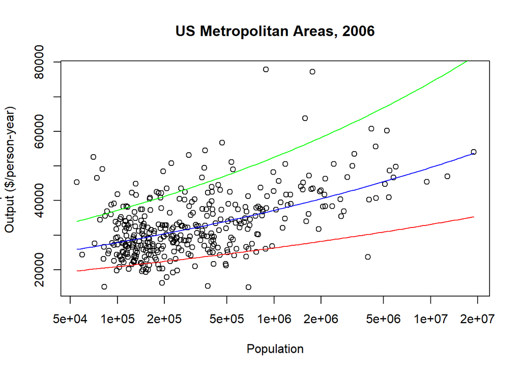

```r
library(ggplot2)
plot(pcgmp~pop, data=gmp, log="x", xlab="Population", ylab="Per-Capita Economic
     Output ($/person-year)", main="US Metropolitan Areas, 2006")
curve(6611*x^(1/8), add = TRUE, col = "blue")
curve(6611*x^{0.1}, add = TRUE, col = "red")
curve(6611*x^{0.15}, add = TRUE, col = "green")
```

2. Write a function, called `mse()`, which calculates the mean squared error of the model on a given data set. `mse()` should take three arguments: a numeric vector of length two, the first component standing for $y_0$ and the second for $a$; a numerical vector containing the values of $N$; and a numerical vector containing the values of $Y$. The function should return a single numerical value. The latter two arguments should have as the default values the columns `pop` and `pcgmp` (respectively) from the `gmp` data frame from lecture. Your function may not use `for()` or any other loop. Check that, with the default data, you get the following values.

```r
mse <- function(vector) {
  #beta0 <- 6611
  #beta1 <- 0.15
  beta0 <- vector[1]
  beta1 <- vector[2]
  X <- gmp$pop
  Y <- gmp$pcgmp
  difference <- Y - beta0*X^(beta1)
  mse <- (1/nrow(gmp))*(sum(difference^2))
  #mse
  return(mse)}
```

```r
 mse(c(6611,0.15))
```

```
## [1] 207057513
```

```r
#[1] 207057513
mse(c(5000,0.10))
```

```
## [1] 298459914
```

```r
#[1] 298459915
```

4. R has several built-in functions for optimization, which we will meet as we go through the course. One of the simplest is `nlm()`, or non-linear minimization. `nlm()` takes two required arguments: a function, and a starting value for that function. Run `nlm()` three times with your function `mse()` and three starting value pairs for $y0$ and $a$ as in

```
nlm(mse, c(y0=6611,a=1/8))
```

What do the quantities `minimum` and `estimate` represent? What values does it return for these?